# A3: SPL Library Checkouts

```r
library(tidyverse)
```

```r
library(dplyr)
library(broom)
library(ggplot2)
```

### Introduction

We will be analyzing checkout data from the Seattle Public Library to understand borrowing patterns and identify popular books and materials. This information can be useful for promoting literacy and access to knowledge, as well as informing marketing strategies for publishers and authors. It can also provide insights into broader cultural and social trends.

```r
data <- read.csv("/Users/theophilasetiawan/Documents/INFO 201 (main)/Info201code/a3-spl-checkouts-theophilaabigail/2017-2023-10-Checkouts-SPL-Data.csv")
```

```r
head(data)
```

```
##   UsageClass CheckoutType MaterialType CheckoutYear CheckoutMonth Checkouts
## 1    Digital    OverDrive        EBOOK         2017             8        13
## 2   Physical      Horizon         BOOK         2017             8        23
## 3    Digital       Hoopla        MUSIC         2017             1        33
## 4    Digital        Zinio     MAGAZINE         2017             1        76
## 5    Digital       Hoopla        MOVIE         2017             1        20
## 6    Digital    OverDrive        EBOOK         2017             1        30
##                                                                                  Title
## 1                                                                         Among Others
## 2 Biscuit feeds the pets / story by Alyssa Satin Capucilli ; pictures by Pat Schories.
## 3                                                                            24K Magic
## 4                                                                              Outside
## 5                                                           The Men Who Stare at Goats
## 6                                                                       Modern Romance
##   ISBN                        Creator
```

[output cut: 20 more lines]

```r
nrow(data)
```

```
## [1] 816354
```

### The Dataset

- Who collected/published the data?  
  The establishment that collected and published the data is The Seattle Public Library or SPL.
- What are the parameters of the data (dates, number of checkouts, kinds of books, etc.)? In the original data, there are 42 million rows and 12 columns. The columns represent the books’ unique characteristics, which are UsageClass (denotes if item is “physical” or “digital”), CheckoutType (denotes the vendor tool used to check  
  out the item), MaterialType (describes the type of item checked out (examples: book, song movie, music, magazine)),  
  CheckoutYear (the 4-digit year of checkou), CheckoutMonth (the month of checkout), Checkouts (a count of the number of  
  times the title was checked out within the “Checkout Month”), Title, ISBN, Creator, Subjects, Publisher, and PublicationYear.
- How was the data collected or generated?  
  The data was collected based on the check outs done by the customers at The Seattle Public Library.
- Why was the data collected?  
  Why the data was collected was not mentioned.
- What, if any, ethical questions do you need to consider when working with this data?  
  There are not any apparent questions of power or ethical questions to think about with the data.
- What are possible limitations or problems with this data? (at least 200 words) Working with the library dataset we are working with can pose various limitations and problems. One issue is incomplete or missing data. The dataset may lack critical information about the purchases, such as the cost of each item or the vendor from which the library procured it. This can make it challenging to draw meaningful insights from the data and understand the library’s spending habits accurately.

  There are a lot of missing columns which indicate incompleteness of data and could sometimes be a challenge when trying to make insights, however this could be handled by adding codes that do not take into accounts empty columns. The dataset could also be inconsistent in formatting some values, which could be hard to work with since some values will get ignored when filtered. For example, some values in the publication year column is written inside brackets, but some are not. If filtered, these values have potential to be excluded from the analysis if the dataset is not cleaned beforehand. To overcome these challenges, data cleaning is essential. Data cleaning involves identifying and correcting inconsistencies and errors in the data. This process can be time-consuming and requires expertise in data cleaning techniques. However, it is a crucial step in preparing the data for analysis, as it ensures that the data is accurate and reliable.

### First Trends Over Time Chart

I included this chart because I was interested in finding out if people prefer digital or physical media in this age of digitalization.

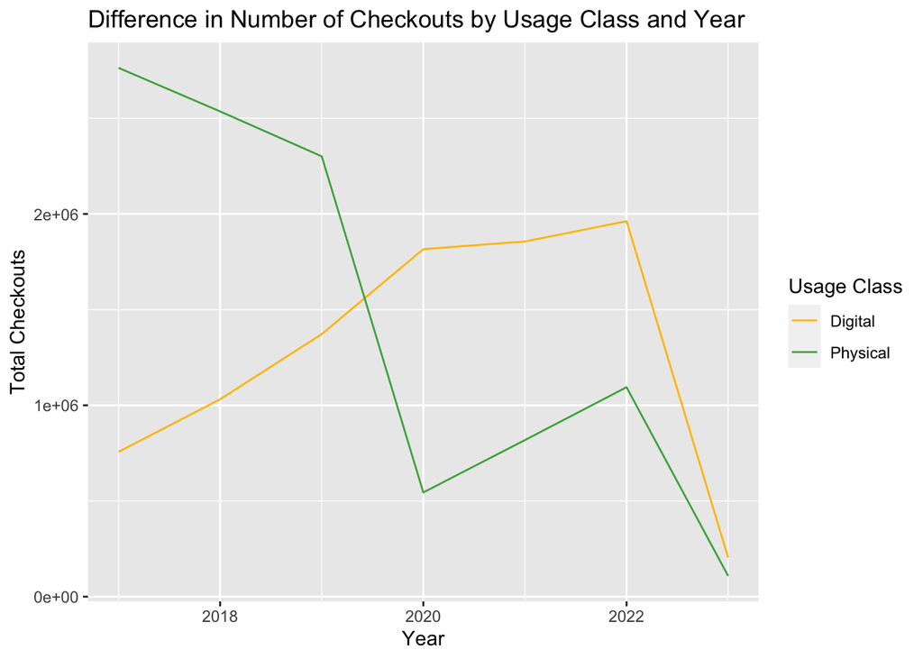

### Second Trends Over Time Chart

I included this chart because I wanted to see if the top overall publishers had stable number of sales throughout the years, and I also wanted to know how much COVID-19 affected the number of sales of books.

[figure not shown]

### Chart 3

The histogram below shows the overall top 5 creators/authors from 2017 to the present. It is interesting how I could recognize all 5 creators/authors because they all produce the same genre of books, which is children’s books/cartoons. From the graph, we could learn that a significantly big portion of sales of the library is sales of children’s books.

I included this graph because I wanted to know if my favorite author(s) are among the top 5 creator/authors, but turns out the top 5 authors are the authors of the books I used to read as a child.

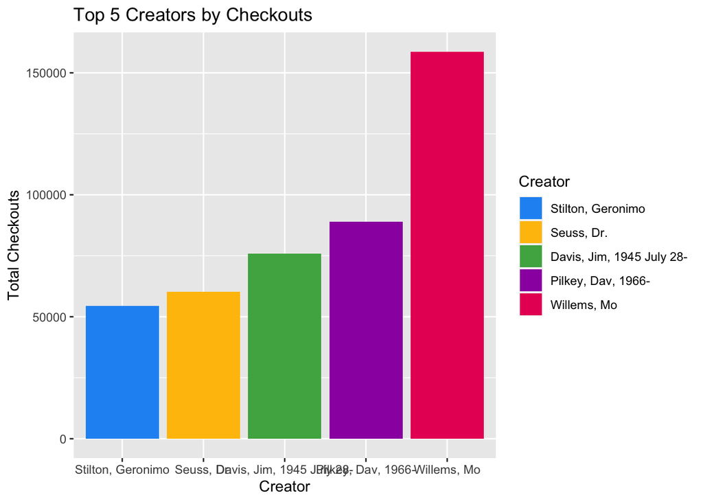